# Problem Set 1

Due date: 18 September

Please upload your completed assignment to the ELMs course site (under the assignments menu). Remember to include an annotated script file for all work with R and show your math for all other problems (if applicable, or necessary). Please also upload your completed assignment to the Github repository that you have shared with us. *We should be able to run your script with no errors.*

**Total points: 25**

*Points: 5*

Using the `gss` dataset (which has survey data with the individual respondent as the unit of analysis), create a frequency distribution and bar chart for each of the following variables: `degree` and `partyid_3`. Describe the distribution of each variable in detail.

**Note**

The `gss` dataset can be found in `poliscidata::gss`. Take a look at `?gss` to see what these variables measure.

#frequency distribution code

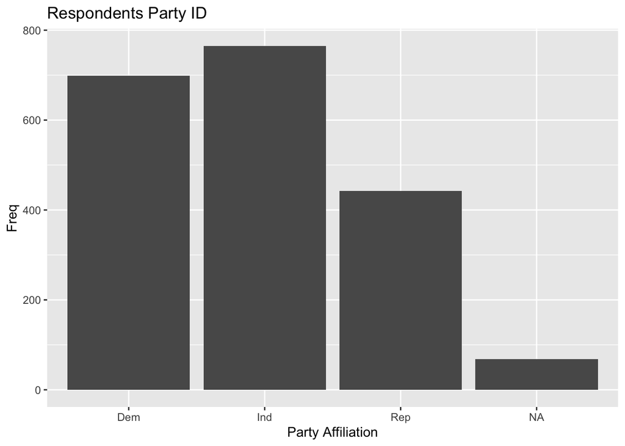

```r
library(poliscidata)
library(gss)
library(skimr)
library(tidyverse)
library(ggplot2)

ggplot(gss,aes(x = partyid_3))+
geom_bar()+
labs(x = "Party Affiliation", y="Freq", title="Respondents Party ID")
```

```r
freq(gss$partyid_3, plot = F)
```

```
gss$partyid_3
      Frequency Percent Valid Percent
Dem         699  35.410         36.67
Ind         765  38.754         40.14
Rep         442  22.391         23.19
NA's         68   3.445
Total      1974 100.000        100.00
```

The distribution is rather evenly spread out among those identified as “Independent” (38.7%) and Democrat (35.4%), followed by those identified as “Republican (22.3%). A small chunk of respondents (3.4%) are not affiliated with the mentioned party identification.

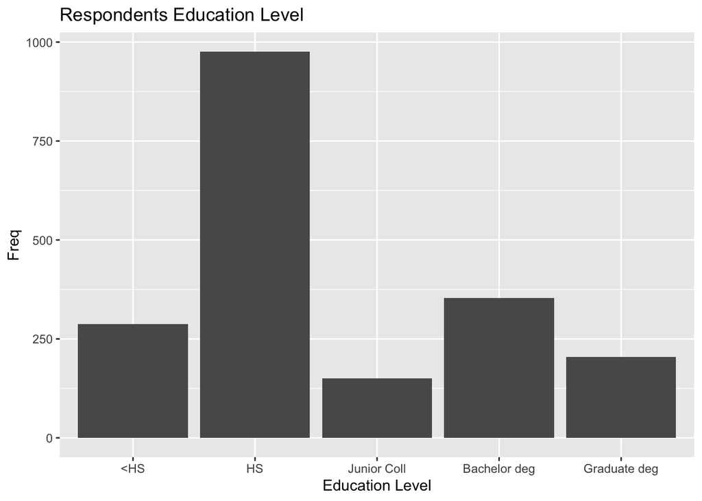

```r
ggplot(gss, aes(x = degree))+
geom_bar()+
labs(x = "Education Level", y="Freq", title="Respondents Education Level")
```

```r
freq(gss$degree, plot = F)
```

```
gss$degree
             Frequency Percent
<HS                288  14.590
HS                 976  49.443
Junior Coll        151   7.649
Bachelor deg       354  17.933
Graduate deg       205  10.385
Total             1974 100.000
```

The responses are dominated by high school graduates 49.4%, followed by bachelor degree (17.9%), less than high school (14.5%), graduate degree (10.3%), and junior college (7.6%), respectively. Compared to the partyid_3 variable, this variable is much more concentrated as it falls mostly under high school degree.

## Question 2

Examine the following vector of (fake) student IQ test scores:

```r
iq <- c(
  145, 139, 126, 122, 125, 130, 96, 110, 118, 118, 101, 142, 134, 124, 112, 109,
  134, 113, 81, 113, 123, 94, 100, 136, 109, 131, 117, 110, 127, 124, 106, 124,
  115, 133, 116, 102, 127, 117, 109, 137, 117, 90, 103, 114, 139, 101, 122, 105,
  97, 89, 102, 108, 110, 128, 114, 112, 114, 102, 82, 101
)
```

### Part A

*Points: 5*

Find the five-number summary, mean, and standard deviation for these data. Also, are there any suspected outliers in the distribution? If so, what are they and how do you know?

```r
library(skimr)
skimr::skim(iq)
```

Data summary

| Name | iq |
| --- | --- |
| Number of rows | 60 |
| Number of columns | 1 |
| _______________________ |  |
| Column type frequency: |  |
| numeric | 1 |
| ________________________ |  |
| Group variables | None |

**Variable type: numeric**

| skim_variable | n_missing | complete_rate | mean | sd | p0 | p25 | p50 | p75 | p100 | hist |
| --- | --- | --- | --- | --- | --- | --- | --- | --- | --- | --- |
| data | 0 | 1 | 114.98 | 14.8 | 81 | 104.5 | 114 | 125.25 | 145 | ▂▅▇▅▃ |

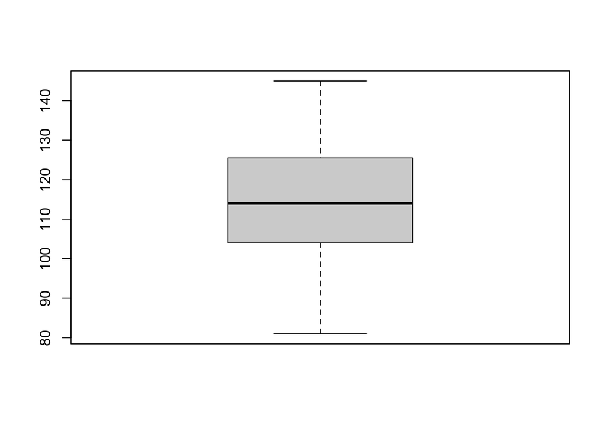

```r
boxplot(iq)
```

There are no suspected outliers as can be found in the boxplot.

### Part B

*Points: 5*

In large populations, IQ scores are standardized to have a mean of 100 and a standard deviation of 15. In what way does the distribution among these students differ from the overall population?

The IQ scores in the overall populations (114.98) are higher than in the large populations (100). The standard deviation of the overall population (14.8) is slightly less than the large population (15). This indicates that the data of overall population is slightly less spread out compared to the large population.

## Question 3

*Points: 5*

A polling firm is interested in determining how different characteristics of an individual affect vote choice. They record the following characteristics for each survey respondent - race, age, household income, and party affiliation. What “type” of variable does each characteristic most likely represent?

#Types of variable

race: categorical (nominal)

age: continuous

household income: continuous

party affiliation: categorical (It depends on how you use it, it could be measured as nominal, but it could also be ordinal if you use the Likert scale - very weak democrat, weak democrat, democrat, strong democrat, very strong democrat, etc.)

## Question 4

*Points: 5*

Using the `states` dataset (the unit of analysis is each U.S. state), generate a box plot and density curve for each of the `vep12_turnout` and `cig_tax12` variables. Describe the distribution of each variable in detail.

**Note**

The `states` data set can be found in `poliscidata::states`. Take a look at `?states` to see what these variables measure.

#boxplot

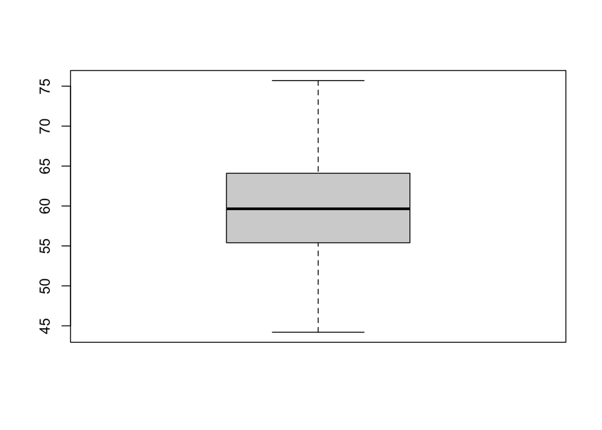

```r
boxplot(states$vep12_turnout)
```

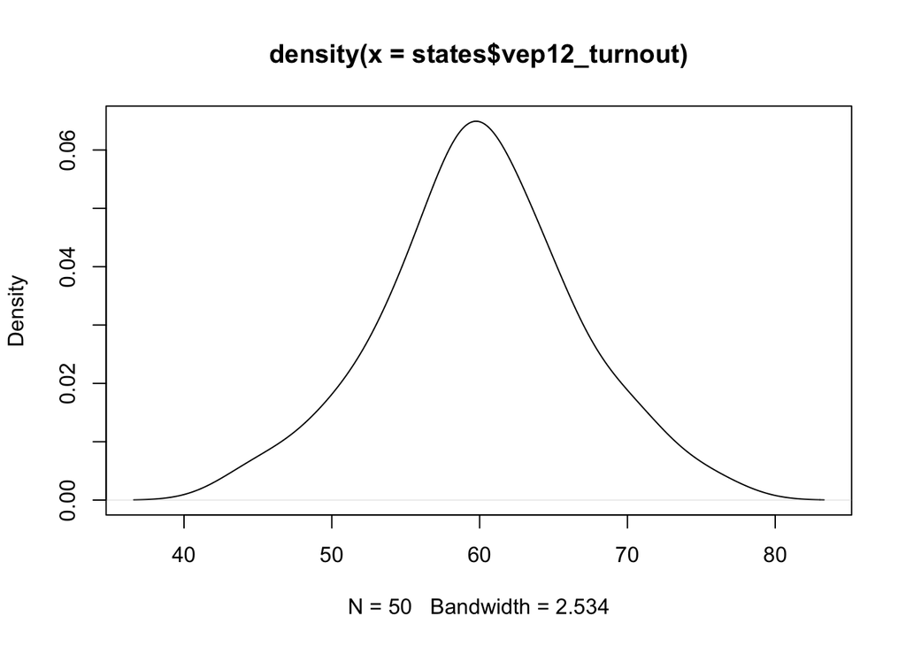

```r
plot(density(states$vep12_turnout))
```

The data for the vep12_turnout is symmetrical distribution. And the boxplot shows no outliers.

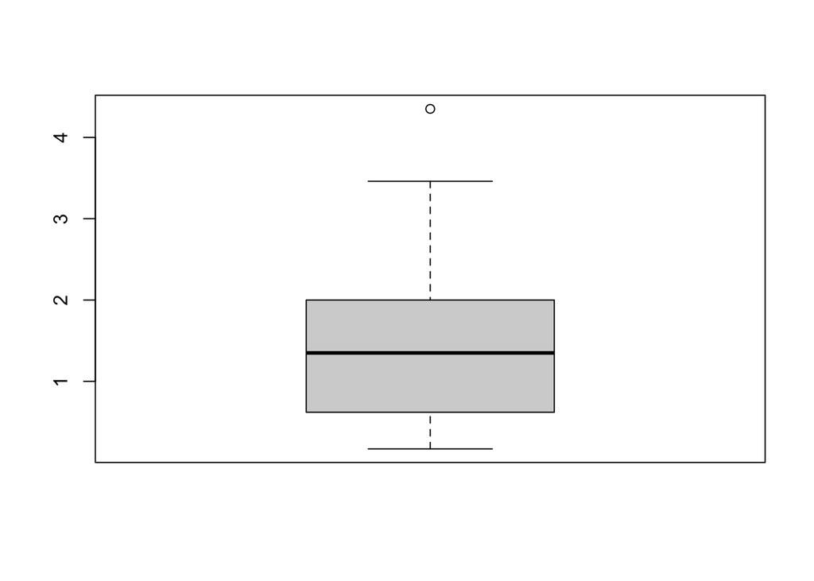

```r
boxplot(states$cig_tax12)
```

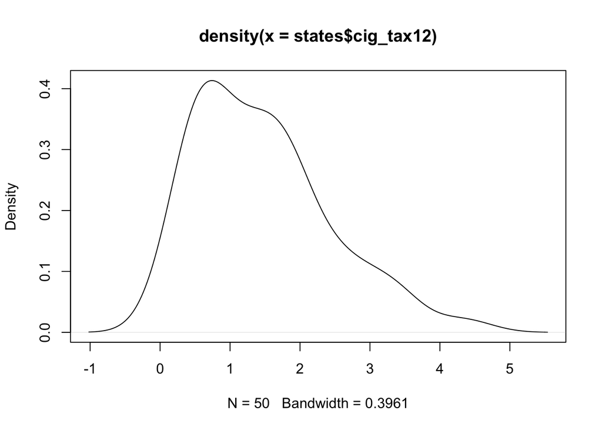

```r
plot(density(states$cig_tax12))
```

The density plot of cig_tax12 variable is positively skewed. And the boxplot shows an outlier.